# DataViz Wajd Meskini Lab3

Wajd

13 mars 2018

# 1- Data Understanding

## Data Collection

We will recover the database from a file, AssuranceExpertsInc.txt, containing informations about clients grouped by postal code.

```r
DirtyInsurance <- read.table("AssurancExpertsInc.txt", header=T,fill=T, encoding="utf-8", sep="\t", dec=".",quote = "", na.string=" " )
```

## Data Description

The columns are divided between sociodemographic columns, and columns related to insurance. Besides, the column names are not significant. Thus we have recovered the true column names from the descriptive file and we will assign each name to its respective column.

```r
columnNames<- read.table("columns.txt", header=F,fill=T, encoding="utf-8", sep="\n", dec=".",quote = "", na.string=" " )
colnames(DirtyInsurance)<-as.vector(columnNames$V1)
```

# 2- Data Preparation

We have noticed that the modalities of each column range from 0 to 40, with each modality representing a certain real world modality. Our values are not ordinal, thus we will have to correctly identify every modality with its respective real world modality, and we will have to dummify our dataset.

## Data Construction

First, we recover the customer subtype, and we will assign the modalities to the respective columns.

```r
L0<- read.table("L0.txt", header=F,fill=T, encoding="utf-8", sep="\n", dec=".",quote = "", na.string=" " )
CustomerSubtypeDummies=dummy(DirtyInsurance$CustomerSubtype, sep = "_")
colnames(CustomerSubtypeDummies)<-as.vector(L0$V1)
```

```r
L1<- read.table("L1.txt", header=F,fill=T, encoding="utf-8", sep="\n", dec=".",quote = "", na.string=" " )
CustomerAgeDummies=dummy(DirtyInsurance$Avgage, sep = "_")
colnames(CustomerAgeDummies)<-as.vector(L1$V1)
```

```r
L2<- read.table("L2.txt", header=F,fill=T, encoding="utf-8", sep="\n", dec=".",quote = "", na.string=" " )
CustomerMainType=dummy(DirtyInsurance$CustomerMainType, sep = "_")
colnames(CustomerMainType)<-as.vector(L2$V1)
```

Now, we will have to get rid of two columns. STATUS says if the column is a part of the training set or the testing set. CLASS is our target value. We will have to skip both of these before we dummify the rest of the dataset.

```r
isTrain=DirtyInsurance$STATUS
target=DirtyInsurance$CLASS
targetFactor=DirtyInsurance$CLASS
target=as.numeric(target)
CleanerInsurance<-DirtyInsurance[,!(colnames(DirtyInsurance)%in% c("CLASS","STATUS" ))]
```

Now, we dummify all the remaining values.

```r
for(b in colnames(CleanerInsurance[,6:length(colnames(CleanerInsurance))])) CleanerInsurance[[b]] <- as.factor(CleanerInsurance[[b]])
Dummified=dummy.data.frame(CleanerInsurance[,6:length(colnames(CleanerInsurance))], sep = "_")
```

## Data Integration

Now we integrate all dummified values into one dataset.

```r
AllDummies=cbind(CustomerMainType,CustomerSubtypeDummies, CustomerAgeDummies,Dummified)
```

## Data Exploration

We have little knowledge of insurance and we have little time to spare to understand the topic entirely. We could start setting assumptions but it will be a long process of trial and error we don’t want.

### Hypothesis and outline

The idea would be to study the correlation between every single dummy value and the target value. Then, by plotting the top 10 most positively correlated attributes and the top 10 most negatively correlated attributes, we will be able to make a targeted vizualization, reaching directly the most important values.

### Correlations

First, we start with the correlations

```r
for(b in colnames(Dummified)) Dummified[[b]] <- as.numeric(Dummified[[b]])
correlations=apply(Dummified,2, function(col)cor(col, target))
```

Then we plot the most positively correlated attributes

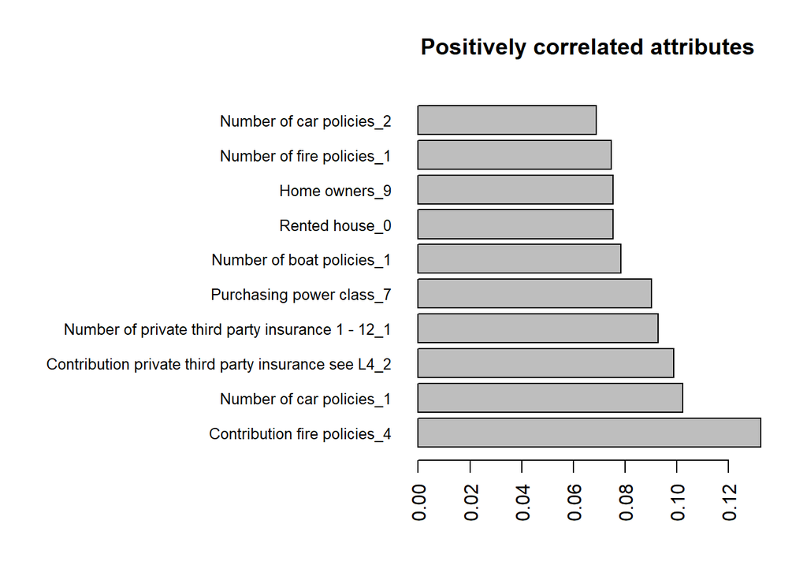

```r
par(las=2) # make label text perpendicular to axis
par(mar=c(5,18,4,2)) # increase y-axis margin.
heads=sort(correlations, decreasing=T)
barplot(head( heads[2:length(heads)],10), main="Positively correlated attributes", horiz=TRUE,names.arg=head(colnames( heads[2:length(heads)]),10),  cex.names=0.8)
```

Now, we plot the most negatively correlated attributes

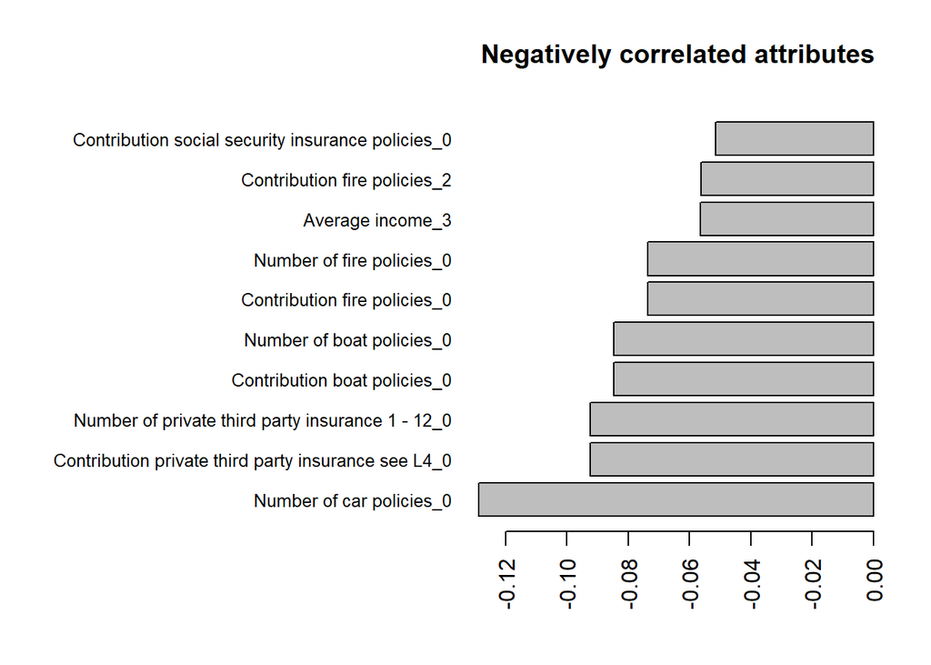

```r
par(las=2) # make label text perpendicular to axis
par(mar=c(5,18,4,2)) # increase y-axis margin.
tails=sort(correlations, decreasing=F)
barplot(head( tails[2:length(tails)],10), main="Negatively correlated attributes", horiz=TRUE,names.arg=head(colnames( tails[2:length(tails)]),10),  cex.names=0.8)
```

Now, we move straight to plotting the select values’ confusion matrices

### Conclusion and selected attributes

Now, we move straight to plotting the select values’ confusion matrices

Contribution fire policies_4 Number of car policies_1 Purchasing power class_7 Rented house_0 House owners_9 Number of fire policies_1 Number of car policies_2 Number of car policies_0 Contribution boat policies_0 Contribution fire policies_0 Average income_3 Contribution fire policies_2

We start with the positive correlations

### Positive correlations

#### Contribution to car policies from 500 to 999

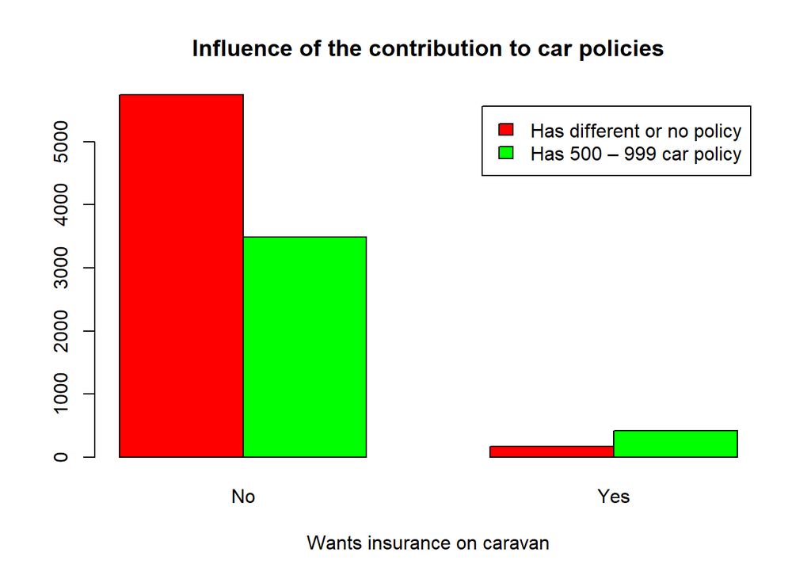

```r
counts <-table(Dummified$`Contribution car policies_6`, targetFactor)
barplot(counts,main="Influence of the contribution to car policies",
        xlab="Wants insurance on caravan", col=c("red","green"),
        legend = c("Has different or no policy","Has 500 – 999 car policy"), beside=TRUE)
```

We can see here that those who spend between 500 and 999 on car policies are more likely to want a caravan.

It can be explained by the fact that those having a car policy both have a car, have an expensive car insurance and thus have the ability and the culture to have both a caravan and a caravan insurance.

#### Contribution to fire policies from 100 to 199

[figure not shown]

```r
counts <-table(Dummified$`Contribution fire policies_4`, targetFactor)
barplot(counts,main="Influence of the contribution to fire policies",
        xlab="Wants insurance on caravan", col=c("red","green"),
        legend = c("Has 100 – 199 fire policy","Has different or no policy"), beside=TRUE)
```

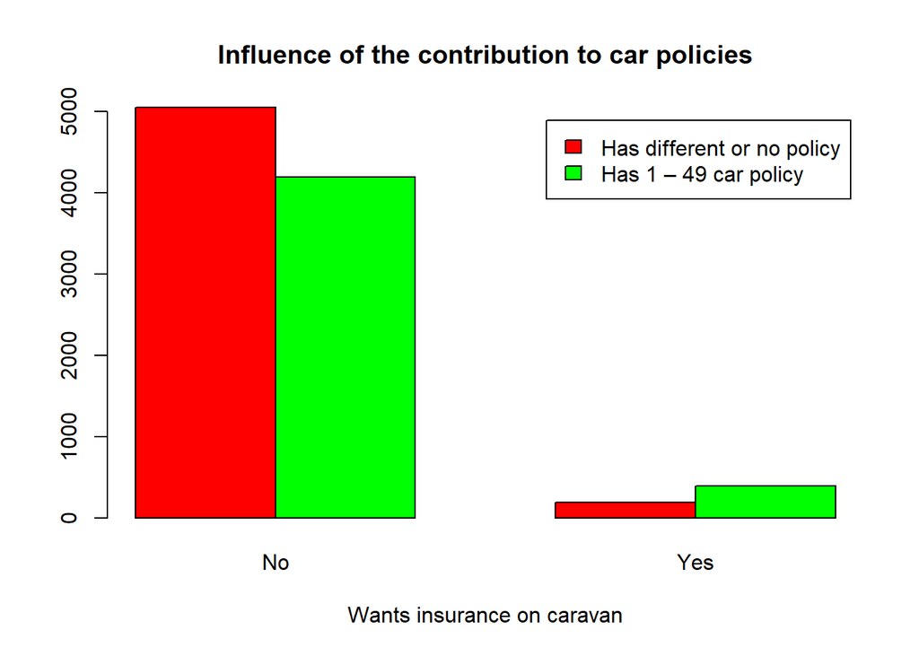

```r
counts <-table(Dummified$`Number of car policies_1`, targetFactor)
barplot(counts,main="Influence of the contribution to car policies",
        xlab="Wants insurance on caravan", col=c("red","green"),
        legend = c("Has different or no policy","Has 1 – 49 car policy"), beside=TRUE)
```

#### Influence of the purchasing power

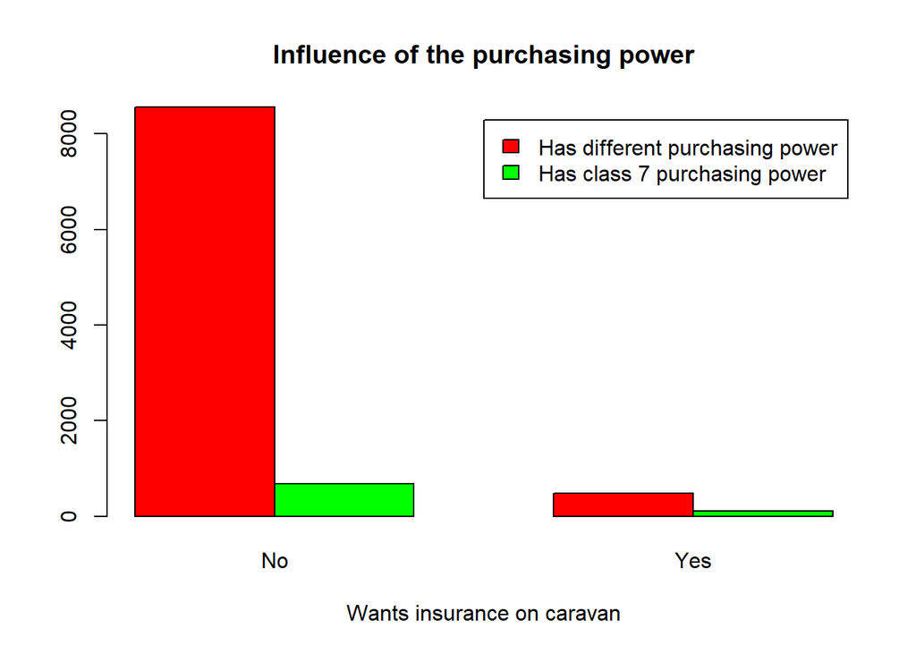

```r
counts <-table(Dummified$`Purchasing power class_7`, targetFactor)
barplot(counts,main="Influence of the purchasing power",
        xlab="Wants insurance on caravan", col=c("red","green"),
        legend = c("Has different purchasing power","Has class 7 purchasing power"), beside=TRUE)
```

#### Influence of owning a home

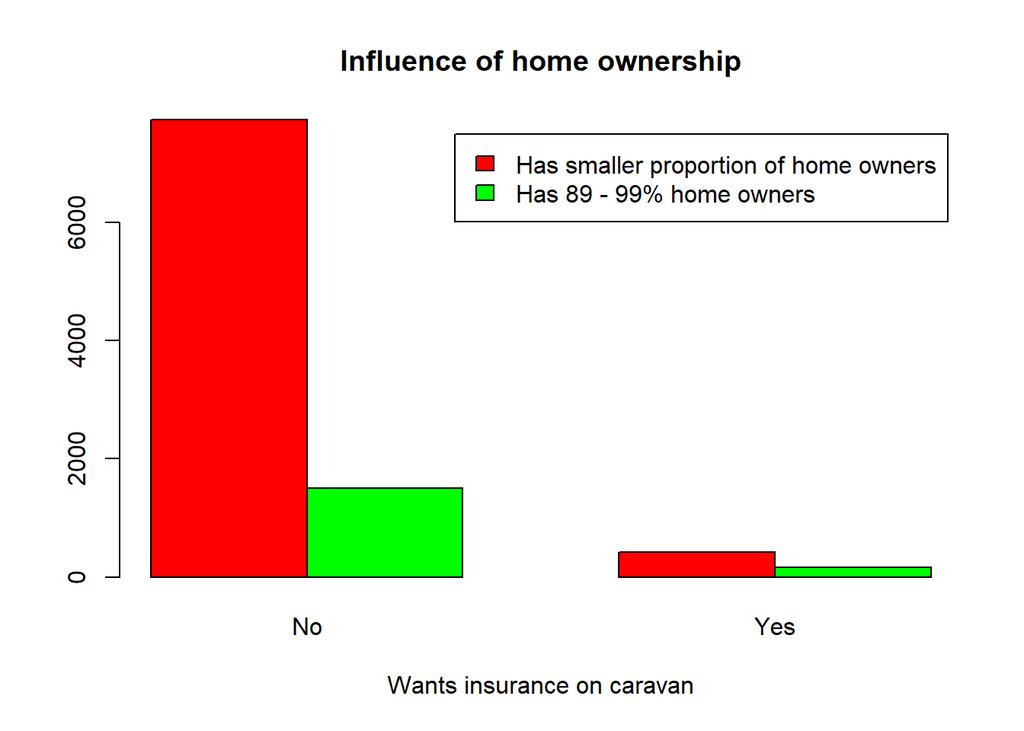

```r
counts <-table(Dummified$`Home owners_9`, targetFactor)
barplot(counts,main="Influence of home ownership",
        xlab="Wants insurance on caravan", col=c("red","green"),
        legend = c("Has smaller proportion of home owners","Has 89 - 99% home owners"), beside=TRUE)
```

#### Influence of renting a home

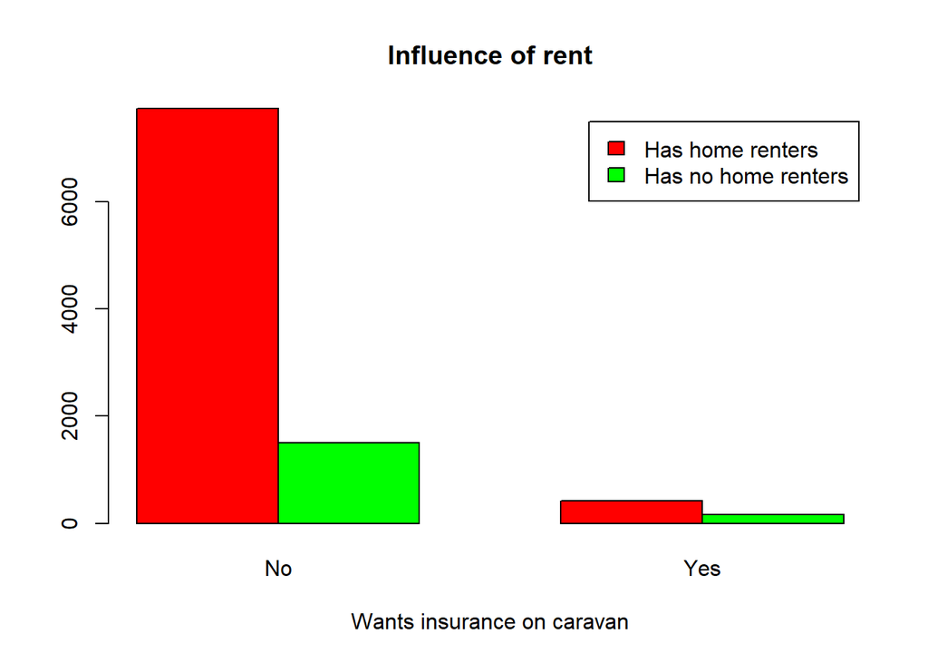

```r
counts <-table(Dummified$`Rented house_0`, targetFactor)
barplot(counts,main="Influence of rent",
        xlab="Wants insurance on caravan", col=c("red","green"),
        legend = c("Has home renters","Has no home renters"), beside=TRUE)
```

Now we will take a look at the negative correlations

### Negative correlations

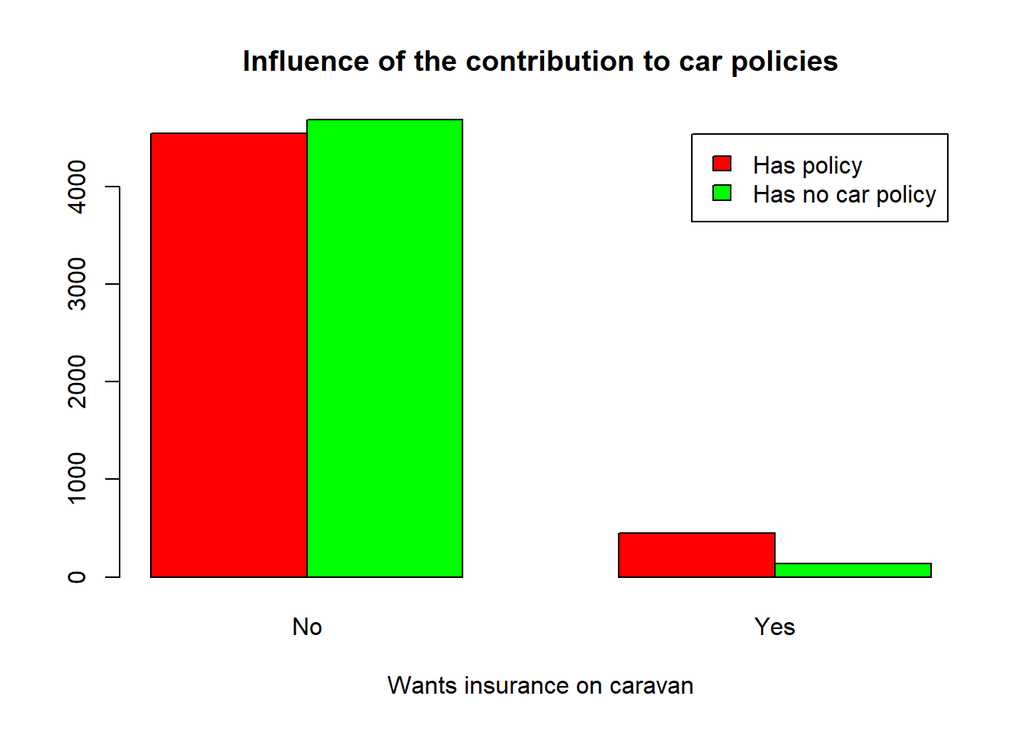

```r
counts <-table(Dummified$`Contribution car policies_0`, targetFactor)
barplot(counts,main="Influence of the contribution to car policies",
        xlab="Wants insurance on caravan", col=c("red","green"),
        legend = c("Has policy","Has no car policy"), beside=TRUE)
```

Here, we notice that most people who contribute to a car policy have a higher chance of saying yes.

#### Influence of the existence of boat policies

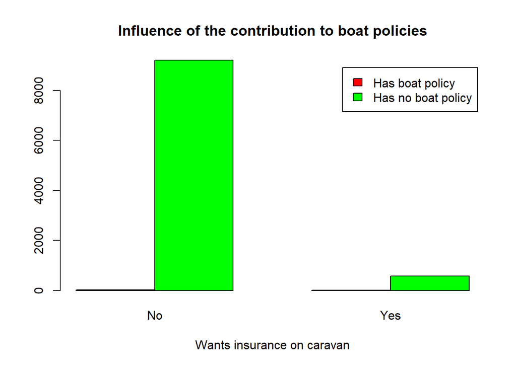

```r
counts <-table(Dummified$`Contribution boat policies_0`, targetFactor)
barplot(counts,main="Influence of the contribution to boat policies",
        xlab="Wants insurance on caravan", col=c("red","green"),
        legend = c("Has boat policy","Has no boat policy"), beside=TRUE)
```

But if we take a look at the proportions, we may notice something

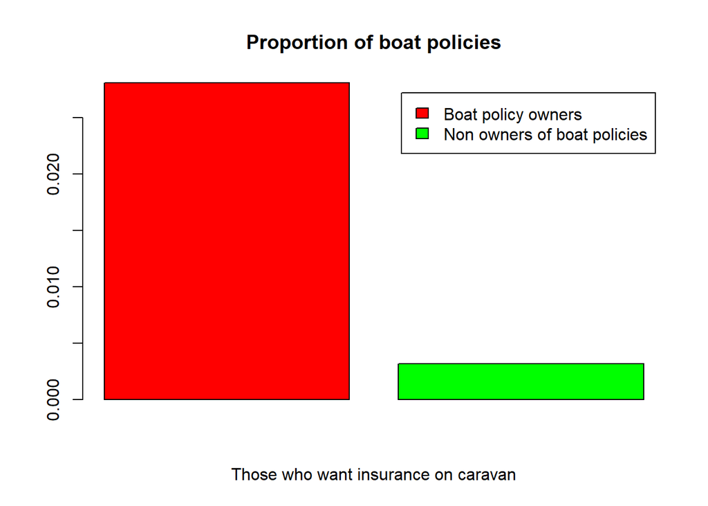

```r
counts.boat=as.data.frame(counts)
Yes=counts.boat$Freq[3]/counts.boat$Freq[4]
No=counts.boat$Freq[1]/counts.boat$Freq[2]

 barplot(c(Yes,No),main="Proportion of boat policies",
        xlab="Those who want insurance on caravan", col=c("red","green"),
        legend = c("Boat policy owners","Non owners of boat policies"), beside=TRUE)
```

Here, the proportion of boat owners is a lot higher than the proportion of non boat owners.